# 09.4_MR_intersection_with_gametophyte_Atallah_DE

Create a mutual rank network and intersect that with Atallah’s antheridogen vs hermaphrodite DE genes.

```r
library(tidyverse)
library(dbscan)    # Contains both DBSCAN and HDBSCAN implementations
library(patchwork)   # For arranging multiple plots
library(topGO)
library(broom)
conflicted::conflicts_prefer(dplyr::rename, dplyr::filter, dplyr::select)
```

```r
CrLFY1 <- "Ceric.33G031700.1"

CrLFY2 <- "Ceric.18G076300.1"
```

load sample info

```r
sample.description <- read.csv("../output/sample.description.gametophyte.no4.5DAG.csv")
```

load DEG list for Atallah

```r
deg <- read_csv("../output/DEG_ALL_Atallah.csv.gz") %>%
  slice_sample(n=nrow(.))
deg
```

| geneID | logFC | logCPM | F | PValue | FDR | GO | GOterms | Best-hit-arabi-name | Best-hit-arabi-defline | Best-hit-clamy-name | Best-hit-clamy-defline | Best-hit-rice-name | Best-hit-rice-defline | Pfam | Panther | ec | KOG | KO |
| --- | --- | --- | --- | --- | --- | --- | --- | --- | --- | --- | --- | --- | --- | --- | --- | --- | --- | --- |
| Ceric.17G002800.1 | -0.8079497917 | 6.307123069 | 1.567265e+01 | 4.067164e-03 | 0.0191616842 | GO:0003676 GO:0003723 GO:0003724 GO:0005524 GO:0006401 | nucleic acid binding; RNA binding; RNA helicase activity; ATP binding; RNA catabolic process | AT1G59760 | RNA helicase, ATP-dependent, SK12/DOB1 protein | Cre02.g117900 | DEAD/DEAH box family ATP dependent helicase | LOC_Os12g18140 | superkiller viralicidic activity 2-like 2, putative, expressed | PF00270 PF00271 PF08148 PF13234 | NA | EC:3.6.4.13 | NA | K12598 |
| Ceric.35G067100.1 | 0.8270676996 | 6.288259191 | 1.923187e+01 | 2.253928e-03 | 0.0142088465 | GO:0016491 GO:0055114 | oxidoreductase activity; | NA | NA | NA | NA | NA | NA | PF07992 | PTHR38688 | NA | NA | NA |
| Ceric.39G013500.1 | 0.0144031463 | 3.700342390 | 4.261502e-03 | 9.495308e-01 | 0.9626001106 | NA | NA | NA | NA | NA | NA | NA | NA | PF08212 | PTHR10612 | NA | NA | NA |
| Ceric.12G086900.1 | 1.2130337916 | 4.222933004 | 1.646533e+01 | 3.538691e-03 | 0.0176450588 | GO:0046872 | metal ion binding | AT5G26749 | C2H2 and C2HC zinc fingers superfamily protein | NA | NA | LOC_Os01g14870 | zinc finger matrin-type protein 5, putative, expressed | PF00642 | PTHR16465 | NA | NA | NA |
| Ceric.30G015100.1 | -0.0281429121 | 3.675919672 | 3.060936e-02 | 8.654019e-01 | 0.8983801977 | GO:0016021 | NA | NA | NA | Cre06.g303900 | (1 of 1) PTHR20855:SF52 - ADIPONECTIN RECEPTOR PROTEIN | LOC_Os06g43620 | haemolysin-III, putative, expressed | PF03006 | PTHR20855 PTHR20855:SF32 | NA | KOG0748 | K07297 |
| Ceric.01G098100.1 | 0.0483690648 | 5.913189210 | 1.081257e-01 | 7.506149e-01 | 0.8054005210 | GO:0005515 | protein binding | AT1G67480 | Galactose oxidase/kelch repeat superfamily protein | NA | NA | NA | NA | PF01344 | PTHR24412 PTHR24412:SF0 | NA | NA | NA |
| Ceric.01G027300.1 | 0.0731856663 | 4.287682625 | 2.210291e-01 | 6.506348e-01 | 0.7200312926 | NA | NA | NA | NA | Cre01.g032600 | Hydroxyproline O-arabinosyl transferase 1 | NA | NA | NA | PTHR31485 | NA | NA | NA |
| Ceric.05G057900.1 | -0.0343214604 | -1.336090630 | 3.337095e-03 | 9.553383e-01 | 0.9666508852 | NA | NA | NA | NA | NA | NA | NA | NA | PF00505 | PTHR13711 PTHR13711:SF147 | NA | KOG0381 | NA |
| Ceric.24G023300.1 | -1.7058603424 | 9.119767761 | 2.831648e+01 | 6.775623e-04 | 0.0080772078 | GO:0005506 GO:0006537 GO:0006807 GO:0008152 GO:0010181 GO:0015930 GO:0016040 GO:0016491 GO:0016638 GO:0016639 GO:0045181 GO:0050660 GO:0055114 | iron ion binding; glutamate biosynthetic process; ; metabolic process; FMN binding; glutamate synthase activity; glutamate synthase (NADH) activity; oxidoreductase activity; oxidoreductase activity, a… | AT5G53460 | NADH-dependent glutamate synthase 1 | Cre13.g592200 | Glutamate synthase, NADH-dependent | LOC_Os01g48960 | glutamate synthase, chloroplast precursor, putative, expressed | PF00310 PF01493 PF01645 PF04898 PF07992 PF14691 | PTHR11938 PTHR11938:SF109 | EC:1.4.1.14 | NA | K00264 |
| Ceric.23G085500.1 | -0.8075973911 | 6.894274265 | 1.246934e+01 | 7.545670e-03 | 0.0267262859 | GO:0005634 GO:0042254 | nucleus; ribosome biogenesis | AT1G42440 | (1 of 2) PTHR12858 - RIBOSOME BIOGENESIS PROTEIN | Cre16.g673700 | (1 of 1) K14799 - pre-rRNA-processing protein TSR1 (TSR1) | LOC_Os11g19250 | AARP2CN domain containing protein, expressed | PF04950 PF08142 | PTHR12858 PTHR12858:SF1 | NA | NA | K14799 |

[output cut: 990 more lines]

load MR network. See script 09.2 for creation. This currently has McConnell DEG info in it and that will need to be replaced

```r
deg.cor <-
  read_csv("../../McConnell_Samples/output/DEG_ALL_WT_male_v_herm_LFY_CORRELATIONS_v2_noSexMR.csv.gz") %>%
  select(-(logFC:FDR)) %>% # remove McConnell data

# Combine Atallah DEGs with LFY correlations and MR
  left_join(deg) %>%
  select(geneID:FDR, starts_with("LFY"), everything())

deg.cor
```

| geneID | LFY1.cor | LFY2.cor | LFY1.MR | LFY2.MR | LFY1.rank | LFY2.rank | GO | GOterms | Best-hit-arabi-name | Best-hit-arabi-defline | Best-hit-clamy-name | Best-hit-clamy-defline | Best-hit-rice-name | Best-hit-rice-defline | Pfam | Panther | ec | KOG | KO | FDR.lt.0.05 | logFC | logCPM | F | PValue | FDR |
| --- | --- | --- | --- | --- | --- | --- | --- | --- | --- | --- | --- | --- | --- | --- | --- | --- | --- | --- | --- | --- | --- | --- | --- | --- | --- |
| Ceric.32G001900.1 | -0.499 | -0.198 | 7756.18856 | 15580.07009 | 6606.5 | 14028.5 | NA | NA | AT4G28740 | (1 of 2) PF11998 - Protein of unknown function (DUF3493) (DUF3493) | Cre06.g266900 | (1 of 2) PF11998 - Protein of unknown function (DUF3493) (DUF3493) | LOC_Os04g42800 | photosystem-II repair protein, putative, expressed | PF11998 | PTHR35498 | NA | NA | NA | TRUE | 0.3048556793 | 5.202237942 | 5.616838e+00 | 4.482309e-02 | 0.0876311709 |
| Ceric.12G010100.1 | -0.615 | 0.226 | 2339.95513 | 13143.49482 | 3428.0 | 12825.5 | GO:0004672 GO:0004713 GO:0005515 GO:0005524 GO:0006468 | protein kinase activity; protein tyrosine kinase activity; protein binding; ATP binding; protein phosphorylation | AT2G16250 | Leucine-rich repeat protein kinase family protein | Cre14.g625050 | (1 of 40) PTHR23257//PTHR23257:SF513 - SERINE-THREONINE PROTEIN KINASE // SUBFAMILY NOT NAMED | LOC_Os03g51440 | LRR receptor-like protein kinase, putative, expressed | PF07714 PF13855 | PTHR27000 PTHR27000:SF96 | EC:2.7.11.1 | KOG1187 | NA | FALSE | -0.6829123906 | 5.129936270 | 5.959294e+00 | 4.008389e-02 | 0.0808366390 |
| Ceric.05G020200.1 | 0.432 | -0.338 | 6765.89669 | 8329.49998 | 8815.0 | 8344.5 | GO:0003723 GO:0003746 GO:0006452 GO:0043022 GO:0045901 GO:0045905 | RNA binding; translation elongation factor activity; translational frameshifting; ribosome binding; positive regulation of translational elongation; positive regulation of translational termination | AT1G13950 | eukaryotic elongation factor 5A-1 | Cre02.g097400 | Eukaryotic initiation factor, eIF-5A | LOC_Os12g32240 | eukaryotic translation initiation factor 5A, putative, expressed | PF01287 | PTHR11673 PTHR11673:SF8 | NA | KOG3271 | K02180 K03263 | TRUE | 0.8825188044 | 9.129493979 | 1.193145e+01 | 8.456088e-03 | 0.0286043911 |
| Ceric.13G006300.1 | 0.132 | 0.633 | 17785.68481 | 1295.54892 | 18581.0 | 1048.0 | GO:0005515 | protein binding | AT4G26700 | fimbrin 1 | Cre16.g679650 | (1 of 1) PTHR19961:SF18 - FI19014P1 | LOC_Os02g48740 | fimbrin-like protein 2, putative, expressed | PF00307 | PTHR19961 PTHR19961:SF25 | NA | NA | NA | TRUE | 0.0625292185 | 6.401219381 | 2.366001e-01 | 6.395384e-01 | 0.7103276746 |
| Ceric.21G033600.1 | 0.695 | -0.402 | 2921.37776 | 8682.86070 | 1743.5 | 6173.5 | NA | NA | AT1G80190 | partner of SLD five 1 | Cre03.g161050 | (1 of 1) K10732 - GINS complex subunit 1 (GINS1, PSF1) | LOC_Os05g37980 | PSF1 - Putative GINS complex subunit, expressed | PF05916 | PTHR12914 PTHR12914:SF2 | NA | KOG3303 | K10732 | TRUE | 0.5601437970 | 3.245160401 | 1.170802e+01 | 8.875058e-03 | 0.0294425251 |
| Ceric.39G054000.1 | 0.719 | -0.257 | 2513.50592 | 13565.22580 | 1318.0 | 11470.0 | NA | NA | NA | NA | Cre06.g261900 | Flagellar Associated Protein 71 | NA | NA | NA | PTHR40429 | NA | NA | NA | TRUE | -0.2229783474 | 3.427097362 | 2.332269e+00 | 1.647108e-01 | 0.2380450128 |
| Ceric.07G000100.1 | -0.522 | -0.192 | 3114.09505 | 13881.82798 | 5920.0 | 14297.0 | GO:0004672 GO:0004713 GO:0005524 GO:0006468 GO:0030247 | protein kinase activity; protein tyrosine kinase activity; ATP binding; protein phosphorylation; polysaccharide binding | AT5G02070 | Protein kinase family protein | Cre16.g649100 | Mitogen-Activated Protein Kinase Kinase Kinase | LOC_Os05g25390 | tyrosine protein kinase domain containing protein, putative, expressed | PF07714 PF13947 | PTHR27005 PTHR27005:SF44 | EC:2.7.11.1 | KOG1187 | NA | FALSE | -0.8135918914 | 4.624369166 | 2.386774e+01 | 1.167406e-03 | 0.0104020351 |
| Ceric.28G047800.1 | 0.759 | -0.166 | 1534.38196 | 16823.28173 | 688.5 | 15440.5 | GO:0004672 GO:0004674 GO:0004713 GO:0005524 GO:0006468 | protein kinase activity; protein serine/threonine kinase activity; protein tyrosine kinase activity; ATP binding; protein phosphorylation | NA | NA | Cre16.g669800 | (1 of 1) K04345 - protein kinase A (PKA) | NA | NA | PF00069 | PTHR24353 | EC:2.7.11.11 | KOG0616 | K04345 | TRUE | 0.4797248066 | 0.099608997 | 2.164972e+00 | 1.789310e-01 | 0.2545435236 |
| Ceric.17G064300.1 | 0.578 | -0.326 | 5852.11244 | 11227.96014 | 4390.0 | 8769.0 | NA | NA | AT3G12170 | Chaperone DnaJ-domain superfamily protein | Cre09.g389550 | DnaJ-like protein | LOC_Os02g10220 | heat shock protein DnaJ, putative, expressed | PF00226 | PTHR24078 PTHR24078:SF267 | NA | KOG0719 | K09529 | TRUE | -0.0273537150 | 5.828399322 | 3.550239e-02 | 8.551742e-01 | 0.8904819907 |
| Ceric.07G041100.1 | -0.288 | -0.114 | 7373.16553 | 16179.51711 | 13552.5 | 17809.5 | GO:0006644 GO:0008152 GO:0016746 | phospholipid metabolic process; metabolic process; acyltransferase activity | AT1G78690 | Phospholipid/glycerol acyltransferase family protein | NA | NA | NA | NA | PF01553 | PTHR12497 PTHR12497:SF1 | EC:2.3.1.23 | NA | K13511 | FALSE | 1.3337631395 | 3.636254341 | 3.755658e+01 | 2.649984e-04 | 0.0053202080 |

[output cut: 990 more lines]

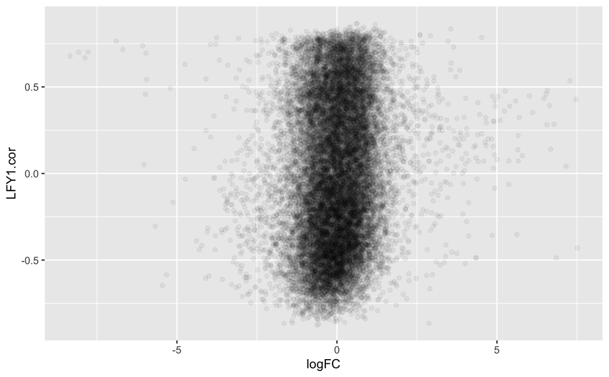

```r
deg.cor %>%
  ggplot(aes(x=logFC, y=LFY1.cor)) +
  geom_point(alpha=.05)

ggsave("../output/Atallah_LFY1_cor_logFC.png", width=6, height=4)
```

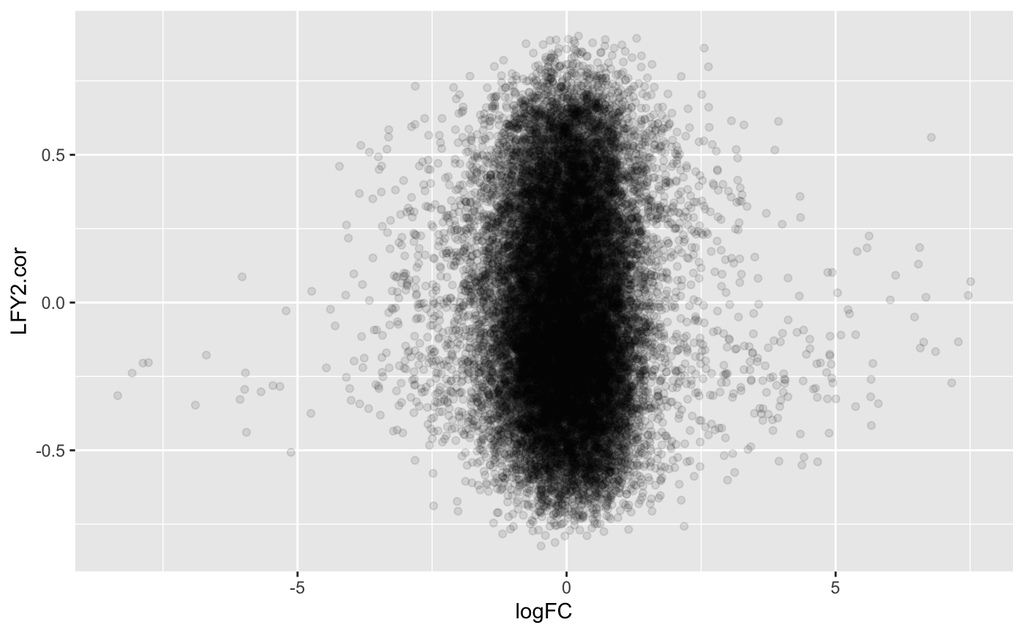

```r
deg.cor %>%
  ggplot(aes(x=logFC, y=LFY2.cor)) +
  geom_point(alpha=.1)
```

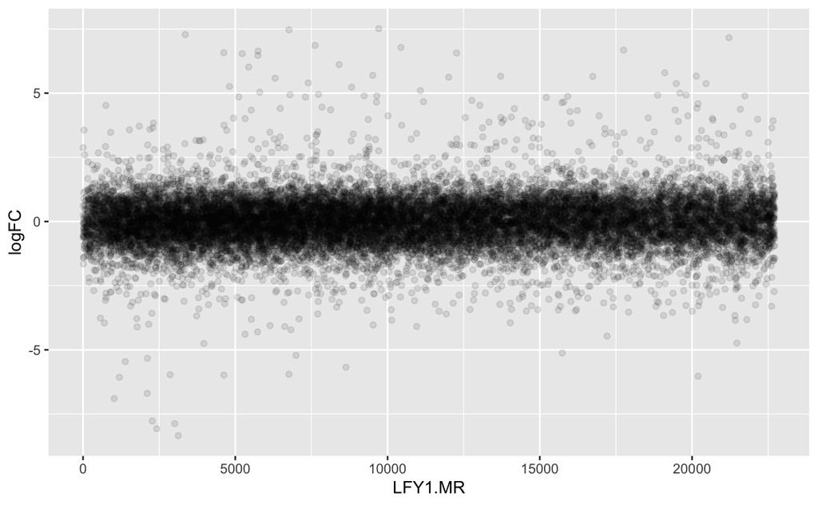

```r
deg.cor %>%
  ggplot(aes(x=LFY1.MR, y=logFC)) +
  geom_point(alpha=.1)
```

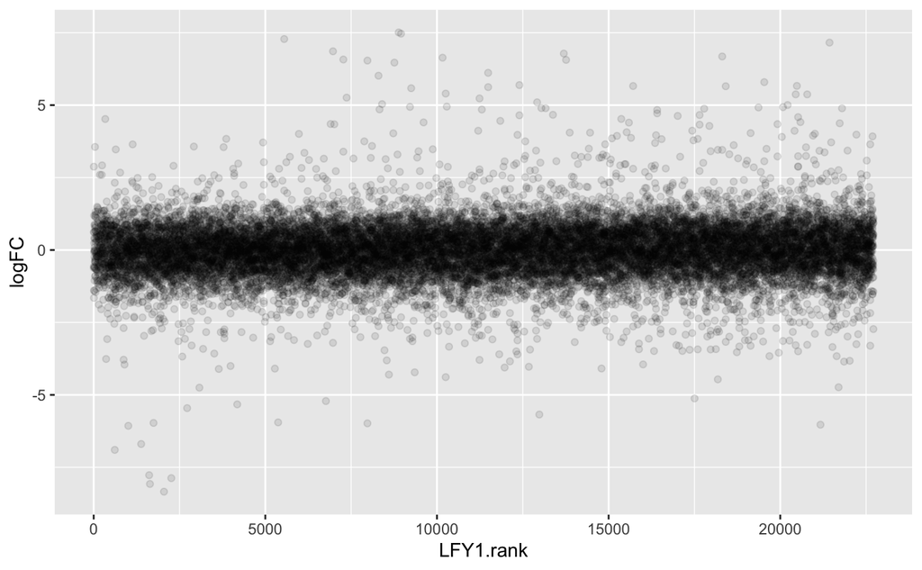

```r
deg.cor %>%
  ggplot(aes(x=LFY1.rank, y=logFC)) +
  geom_point(alpha=.1)
```

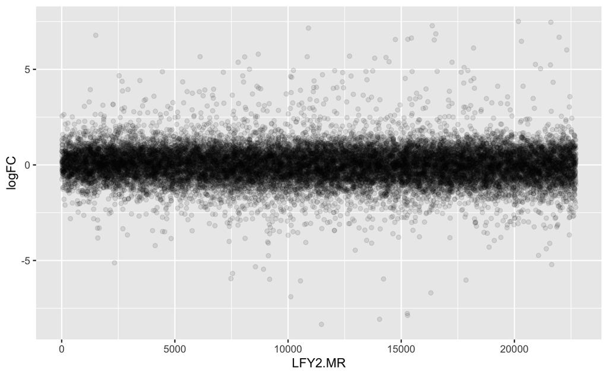

```r
deg.cor %>%
  ggplot(aes(x=LFY2.MR, y=logFC)) +
  geom_point(alpha=.1)
```

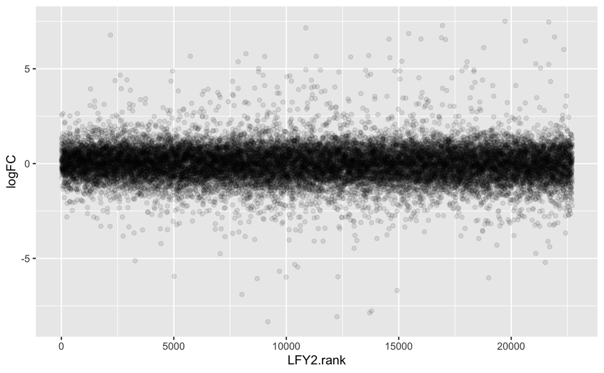

```r
deg.cor %>%
  ggplot(aes(x=LFY2.rank, y=logFC)) +
  geom_point(alpha=.1)
```

## color points by McConnell LFY1 Cluster

Create a column for being in cluster 2 and save output

```r
mcconnell_lfy_cluster <- read_csv("../output/LFY1_gam_sex_cluster_noSexSamples.csv.gz") %>%
  select(geneID, in_LFY1_cluster)
```

Where is this cluster on the cor.plot?

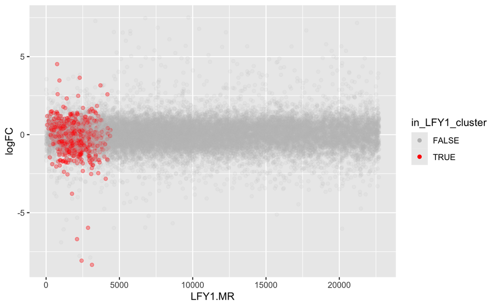

```r
deg.cor %>% left_join(mcconnell_lfy_cluster) %>%
  #arrange(in_LFY1_cluster) %>%
  ggplot(aes(x = LFY1.MR, y = logFC, color = in_LFY1_cluster, alpha = in_LFY1_cluster)) +
  geom_point() +
  scale_alpha_manual(values = c("TRUE" = 0.35, "FALSE" = 0.1)) +
  scale_color_manual(values = c("TRUE" = "red", "FALSE" = "gray")) +
  guides(color = guide_legend(override.aes = list(alpha = 1)))
```

## Compare LFY1 and LFY2 MR in cluster

```r
deg.cor %>%
  mutate(upMale = logFC < -1 & FDR < 0.01) %>%
  t.test(LFY1.MR ~ upMale, data = .)

deg.cor %>%
  mutate(upMale = logFC < -1 & FDR < 0.01) %>%
  t.test(LFY2.MR ~ upMale, data = .)
```

```r
deg.cor %>%
  t.test(LFY1.MR ~ in_LFY1_cluster, data = .)

deg.cor %>%
  t.test(LFY2.MR ~ in_LFY1_cluster, data = .)
```

```r
lfy.network.threshold <- deg.cor %>% filter(in_LFY1_cluster) %>% pull(LFY1.MR) %>% max()

fisher.tmp <- deg.cor %>% mutate(LFY1.network = LFY1.MR <= lfy.network.threshold,
                   LFY2.network = LFY2.MR <= lfy.network.threshold,
                   upMale = logFC < 0 & FDR < 0.01)

fisher.test(fisher.tmp$upMale, fisher.tmp$LFY1.network, alternative = "greater")
fisher.test(fisher.tmp$upMale, fisher.tmp$LFY2.network, alternative = "greater")
```

## GO enrichment for LFY1 cluster

```r
gene2GO.list <- deg.cor %>%
  rowwise() %>%
  mutate(GOlist = str_split(GO, pattern = " ")) %>%
  ungroup() %>%
  mutate(GOlist = set_names(GOlist, geneID)) %>%
  pull(GOlist)

cluster.genes <- deg.cor %>%
  mutate(cluster.genes = as.numeric(in_LFY1_cluster)) %>%
  pull(cluster.genes, name = geneID) %>% generics::as.factor()

go.data.cluster <- new("topGOdata", ontology = "BP", description = "In LFY1 Cluster", allGenes = cluster.genes, annot = annFUN.gene2GO, gene2GO = gene2GO.list)

result.cluster <- runTest(go.data.cluster, algorithm = "weight01", statistic = "fisher")

GO.results <- GenTable(go.data.cluster, result.cluster, topNodes = sum(result.cluster@score < 0.05 )) %>%
  dplyr::rename_with( \(x) str_replace(x, "result1|apply.*", "p.value")) %>%
  mutate(p.value = as.numeric(p.value))

GO.results
```

```r
write_csv(GO.results, file = "../output/LFY1_Sex_Cluster_GO_noSexSamples.csv")
```

## Look for overlap with A.t. repro genes in all male vs hermaphrodite DEG

load gene info

```r
Cr_gene_info <- read_csv("../../shared/output/Cr_At_repro_Placket.csv")
```

### Enrichment

For each gene set (up or down), retain genes that are orthologs of A.t. vegetative or one of the reproductive sets and then do Fisher’s exact.

```r
Cr_gene_info_deg <- deg %>%
  select(geneID, logFC, FDR) %>%
  inner_join(Cr_gene_info, by=c("geneID"="Crichardii")) %>%
  select(-Athaliana) %>%
  mutate(upHermaphrodite = FDR < 0.01 & logFC > 0,
         upMale = FDR < 0.01 & logFC < 0) %>%
  select(geneID, starts_with("up"), everything(), -FDR, -logFC)

Cr_gene_info_deg
```

Is it ratio of each reproductive category to all others, or to vegetative specific?

```r
get.fisher <- function(category, module, t = Cr_gene_info_deg) {
  fisher.test(get(category, t), get(module, t), alternative = "greater")
}

fisher.results <- expand_grid(gene.category = colnames(Cr_gene_info)[-1:-2],
                              module = c("upMale", "upHermaphrodite")) %>%
  mutate(fisher = map2(gene.category, module, get.fisher, Cr_gene_info_deg),
         fisher.tidy = map(fisher, tidy)) %>%
  unnest(fisher.tidy) %>%
  rename(fisher.p.value = p.value) %>%
    mutate(fisher.fdr = p.adjust(fisher.p.value, method = "fdr")) %>%
  arrange(fisher.p.value)
```

```r
fisher.results.filter <- fisher.results %>%
  # group_by(module) %>%
  ungroup() %>%
  filter(fisher.fdr < 0.05) %>%
  arrange(module, fisher.fdr) %>%
  select(module, gene.category, estimate, fisher.fdr, everything(), -fisher, -method, -alternative)

#Table 1
write_csv(fisher.results.filter, "../output/male_hermaphrodite_DEG_At_repro_fisher_fdr_0.05.csv")

# Supplemental Table 1
write_csv(fisher.results, "../output/male_hermaphrodite_DEG_At_repro_fisher_all.csv")


fisher.results.filter
```

## Look for overlap with A.t. repro genes in male vs hermaphrodite DEG LFY1 cluster

### Enrichment

For each gene set (up or down), retain genes that are orthologs of A.t. vegetative or one of the reproductive sets and then do Fisher’s exact.

```r
Cr_gene_info_LFY1Cluster <- deg.cor %>%
  select(geneID, in_LFY1_cluster) %>%
  inner_join(Cr_gene_info, by=c("geneID"="Crichardii")) %>%
  select(-Athaliana)

Cr_gene_info_LFY1Cluster
```

Is it ratio of each reproductive category to all others, or to vegetative specific?

```r
get.fisher <- function(category, module, t = Cr_gene_info_LFY1Cluster) {
  fisher.test(get(category, t), get(module, t), alternative = "greater")
}

fisher.results.LFY1.cluster <- expand_grid(gene.category = colnames(Cr_gene_info)[-1:-2],
                              module = "in_LFY1_cluster") %>%
  mutate(fisher = map2(gene.category, module, get.fisher, Cr_gene_info_LFY1Cluster),
         fisher.tidy = map(fisher, tidy)) %>%
  unnest(fisher.tidy) %>%
  rename(fisher.p.value = p.value) %>%
    mutate(fisher.fdr = p.adjust(fisher.p.value, method = "fdr")) %>%
  arrange(fisher.p.value)

write_csv(fisher.results.LFY1.cluster, "../output/male_hermaphrodite_DEG_LFY1_Cluster_At_repro_fisher_all.csv")
```

```r
fisher.results.LFY1.cluster.filter <- fisher.results.LFY1.cluster %>%
  # group_by(module) %>%
  ungroup() %>%
  filter(fisher.fdr < 0.05) %>%
  arrange(module, fisher.fdr) %>%
  select(module, gene.category, estimate, fisher.fdr, everything(), -fisher, -method, -alternative)

write_csv(fisher.results.LFY1.cluster.filter, "../output/male_hermaphrodite_DEG_LFY1_Cluster_At_repro_fisher_fdr_0.05.csv")

fisher.results.LFY1.cluster.filter
```